## 머신러닝 작업과정 이해하기 (파이썬)

### 0 - Before translation

I read [A Comprehensive ML Workflow with Python] in Kaggle. It is about Titanic and I felt familiar. Plus, It is well described how to learn machine learning workflow with python completely. So I decided to start studying Machine Learning with this post.

Origin Post : https://www.kaggle.com/mjbahmani/a-comprehensive-ml-workflow-with-python

### 1 - 소개

저는 케글에서 머신러닝 문제를 어떻게 해결해야 하는지에 대해 초보자들에게 조언을 주고자합니다. 이 글은 파이썬을 이용한 머신러닝 의 흐름을 배우고자 하는 사람들에게 좋은 기회가 되기를 바란다. 나는 2018년도까지 Titanic을 실험(?)한 다양한 방법들을 다뤄왔다. 당신은 완벽한 데이터셋과 함께 ML에 대한 당신의 지식을 학습하고 복습을 할 수 있고, 데이터 사이언스 세계에서 당신의 여행을 위한 작업과정을 기록할 수 있다.

### 2 - Machine Learning

머신러닝은 컴퓨터가 확실하게 프로그램되지 않은 채로 학습하는 능력을 갖게 해주는 연구분야이다.

-Arthur Samuel, 1959

### 2 - 1 기계학습 작업 흐름

만약 머신러닝 책을 읽은 적이 있다면, 데이터 처리하는 방식이 매우 다양하다는 것을 알 것이다. 하지만 모든 문제에 같은 솔루션이 적용될 수 없기 때문에, 가장 최고의 방법은 일반적인 프레임워크를 만들고 그것을 새로운 문제에 적용하는 것이다. 대부분 아래와 같은 절차를 거친다.

1. 문제 정의
1. 문제 특징화
   - 목적
   - 변수
   - 입출력
1. 프레임워크 설정
   - 어떤 툴을 사용할 것인가?
   - jupyter notebook
   - pandas, ...
1. 데이터 분석
   - 데이터 수집
   - 데이터 처리
   - 시각화
   - 전처리
1. 모델 선정
   - 어셈블? DL? Linear based?
1. 학습 적용
1. 모델 유지 보수

### 3 - 문제 정의 현실 (Problem Definition)

기계학습을 시작할때 가장 중요한 점 중 하나는 바로 문제 정의이다. 즉, 당신은 비지니스 문제를 이해해야한다.

- Probelm Feature
- Aim
- Variables
- Inputs & Outputs

### 3 - 1 Problem Feature

침수하는 타이타닉은 역사에서 가장 유명한 난파선 중 이다. 1912년 4월 15일, 타이타닉호의 첫 운항 중에 빙산과 충돌하여 침수하였고, 2224명의 승객과 승무원중 1502의 사상자가 발생하였다. 이것이 DieTanic이라고 불리우는 이유이다.이것은 세계에서 그 누구도 잊을 수 없는 재앙이다.

타이타닉을 만들기 위해 $7.5 million 가 들었고, 충돌로 인해 바다 아래로 가라앉았다. Titanic 데이터셋은 데이터사이언스의 여행을 시작하고 캐글 컴피티션에 참여하려는 초보자들에게 아주 좋은 데이터셋이다.

우리는 기본적인 Titanic 데이터 셋을 사용할 것이다. 이 데이터셋은 11가지의 다른 변수에 관한 정보를 갖는다

1. Survival
2. Pclass
3. Name
4. Sex
5. Age
6. Sibsp
7. Parch
8. Ticket
9. Fare
10. Cabin
11. Embarked

### 3 - 2 Titanic dataset을 사용하는 이유

1. 쉽게 이해가 가능하기 때문에 좋은 프로젝트이다.
2. 속성이 숫자형, 카테고리형이고, 그 데이터를 불러오고 다루는 방법을 알아야한다.
3. 지도학습 알고리즘의 쉬운 연습을 포함하는 ML문제이다.
4. clustering (비지도 학습 알고리즘)프로젝트로 문제를 정의할 수도 있다.

### 3 - 3 목표

목표는 침수하는 타이타닉호에서 승객이 살아남을지 아닐지를 예측하는 것이다. 테스트셋에 있는 승객아이디를 기준으로 당신은 생존을 나타내기 위한 값 0과 1을 예측해야한다.

### 3 - 4 변수

#### Age

```
- 만약 나이가 1 미만이면 분수이다. 나이를 측정할때, xx.5의 형식인가?
```

#### Sibsp

```
- 데이터셋은 가족관계를 정의한다.
    1. Sibling = brother, sister, stepbrother, stepsister
    2. Spouse = husband, wife (정부와 약혼자는 제외하였다.)
```

#### Parch

```
- 데이터셋은 가족관계를 정의한다.
    1. Parent = mother, father
    2. Child = daughter, son, stepdaughter, stepson
    3. 부모님 동반없이 유모와 여행한 아이들은 parch = 0 이다.
```

#### Pclass

```
- 사회-경제적 지위 ( socio-economic status : SES)
    1st = Upper
    2nd = Middle
    3rd = Lower
```

#### Embarked

```
- nominal datatype
```

#### Name

```
- nominal data type
- 이것은 feature engineering에서 성별을 알아내기 위해 사용되곤한다.
```

#### Sex

```
- nominal datatype
```

#### Ticket

```
- 이 변수는 결과값에 영항을 미치지 않는다. 그러므로, 티켓 데이터셋은 분석으로부터 제외한다.
```

#### Cabin

```
- feature engineering에 사용될 수 있는 nominal datatype 이다.
```

#### Fare

```
- Indicating the fare
```

#### PassengerId

```
- 결과값에 영항을 미치지 않는다. 따라서 분석에서 제외한다.
```

#### Survival

```
- 결과값, 0 또는 1
```

### 3 - 4 - 1 Types of Features

#### 3 - 4 - 1 - 1 Categorical

카테고리가 나뉘는 변수는 두개 또는 그 이상의 분류를 갖고, 각각의 값들이 해당 카테고리에 속한다. 예를들어, 성별은 '남자와 여자' 두 개의 카테고리를 가진 변수이다. 이제 우리는 카테고리화 된 변수들를 정렬하거나 순서를 지정할 수 없다. 이 변수들 또한 Nominal 변수로 알려져있기 때문이다.

#### Categorical Features in the dataset : Sex, Embarked

#### 3 - 4 - 1 - 2 Ordinal

서수 변수는 카테고리 변수와 비슷하지만, 서수 변수는 값들 사이의 순서를 지정하거나 정렬을 할 수 있다는 차이점이 있다. 우리가 Tall, Medium, Short를 가진 Height에 대한 특징을 갖고 있다면, Height는 서수 변수이다. 우리는 이 변수를 가지고 상대적인 정렬을 할 수 있다.

#### Ordinal Features in the dataset : PClass

#### 3 - 4 - 1 - 3 Continous

만약 두 점 또는 최대값과 최소값 사이에서 하나의 값을 고를 수 있다면 그 변수는 연속적이라고 불린다.

#### Continous Features in the dataset : Age

### 4 - Inputs & Outputs

### 4 - 1 Inputs

- train.csv
- test.csv

### 4 - 2 Outputs

머신러닝의 점수는 승객의 생사여부를 정확하게 예측한 확률이다. 이것이 '정확도' 이다. 결과는 두개의 행이 되어야 한다.

1. PassengerId
2. Survived (이진수로 나타낸 예측값을 담고있다. 생존자는 1, 사망자는 0)

### 5 - Installation

### 5 - 1 Import

```python
from sklearn.metrics import make_scorer, accuracy_score
from sklearn.model_selection import train_test_split
from sklearn.ensemble import RandomForestClassifier
from sklearn.linear_model import LogisticRegression
from sklearn.metrics import classification_report
from sklearn.model_selection import GridSearchCV
from sklearn.metrics import confusion_matrix
from sklearn.metrics import accuracy_score
from sklearn import preprocessing
import matplotlib.pylab as pylab
import matplotlib.pyplot as plt
from pandas import get_dummies
import matplotlib as mpl
#import xgboost as xgb
import seaborn as sns
import pandas as pd
import numpy as np
import matplotlib
import warnings
import sklearn
import scipy
import numpy
import json
import sys
import csv
import os
```

### 5 - 2 Version

```python
print('matplotlib: {}'.format(matplotlib.__version__))
print('sklearn: {}'.format(sklearn.__version__))
print('scipy: {}'.format(scipy.__version__))
print('seaborn: {}'.format(sns.__version__))
print('pandas: {}'.format(pd.__version__))
print('numpy: {}'.format(np.__version__))
print('Python: {}'.format(sys.version))
```

```
matplotlib: 3.0.2
sklearn: 0.20.1
scipy: 1.1.0
seaborn: 0.9.0
pandas: 0.23.4
numpy: 1.15.4
Python: 3.7.1 (default, Dec 14 2018, 13:28:58)
[Clang 4.0.1 (tags/RELEASE_401/final)]
```

### 5 - 3 Setup

코드를 더 읽기 쉽게 하기 위한 몇가지 설정

```python
sns.set(style='white', context='notebook', palette='deep')
pylab.rcParams['figure.figsize'] = 12,8
warnings.filterwarnings('ignore')
mpl.style.use('ggplot')
sns.set_style('white')
%matplotlib inline
```

### 6 - Exploratory Data Analysis (EDA)

이제 갖고있는 데이터 구조를 변형시키기 위해 그래픽과 수를 다루는 기술을 배울 것이다.

- 어떤 변수들이 흥미로운 관계를 맺고 있는가?
- 어떤 관측이 일반적이지 않는가?
- 특징 분석

이 파트의 마지막에, 당신은 위의 세 질문에 대해 답할 수 있을것이고, 더 나아가 통찰력있고 아름다운 그래프를 만들 수 있을 것이다. 그러면 한번 분석적이고 통계적인 수행을 복습해보자.

1. Data Collection : 데이터 수집
2. Visualization : 데이터 시각화
3. Data Preprocessing : 데이터 전처리
4. Data Cleaning : 데이터 정리

### 6 - 1 Data Collection

데이터 수집은 수집자가 가설을 평가하고 특정 데이터 모음에 대한 결과를 평가할 수 있게 하는 표준화된 방식으로 관심 데이터, 정보 또는 많은 변수를 모으는 과정이다. 이제 Pandas DataFrames를 이용하여 트레이닝 데이터와 테스트 데이터를 불러와보자.

```python
df_train = pd.read_csv('./train.csv')
```

```python
df_test = pd.read_csv('./test.csv')
```

### 6 - 2 - 1 Scatter plot

Scatter plot 은 두 개의 양적 변수 사이의 관계를 나타낸다.

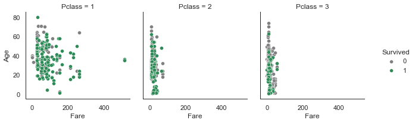

```python
g = sns.FacetGrid(df_train, hue="Survived", col="Pclass", margin_titles = True, palette={1:'seagreen', 0:"gray"})

g = g.map(plt.scatter, "Fare", "Age", edgecolor = "w").add_legend();
```

[figure not shown]

```python
plt.figure(figsize=(8, 6))
plt.scatter(range(df_train.shape[0]), np.sort(df_train['Age'].values))
plt.xlabel('index')
plt.ylabel('Survived')
plt.title('Explore: Age')
plt.show()
```

### 6 - 2 - 2 Box

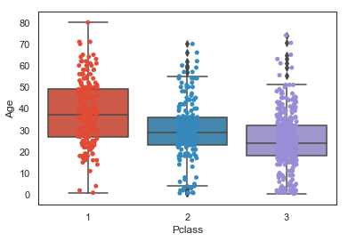

```python
ax = sns.boxplot(x="Pclass", y = "Age", data=df_train)
ax = sns.stripplot(x="Pclass", y="Age", data=df_train, jitter = True, edgecolor="gray")
plt.show()
```

### 6 - 2 - 3 Histogram

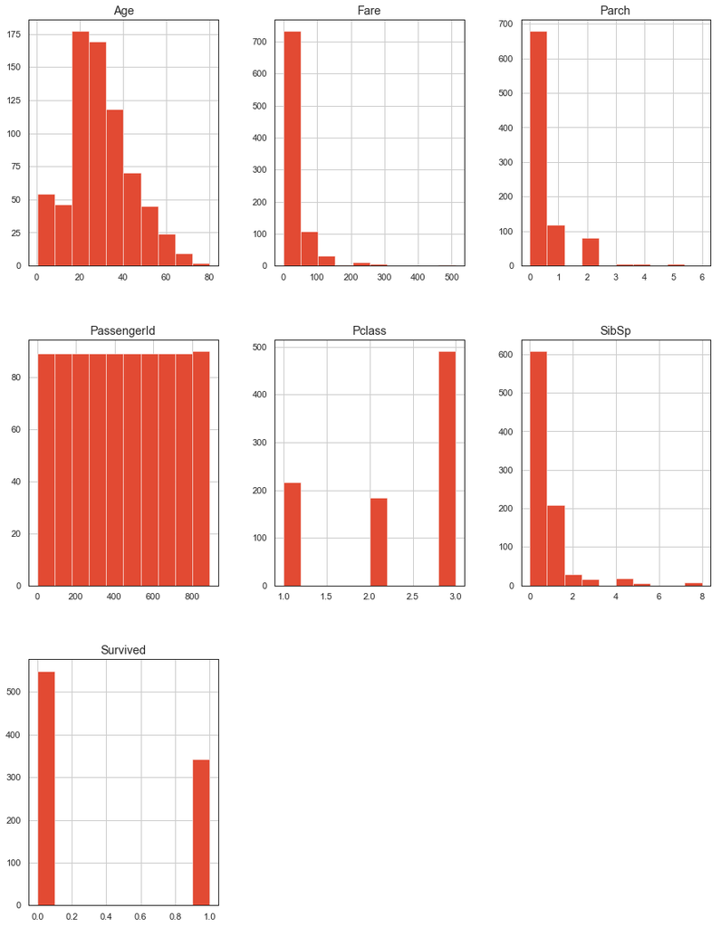

```python
df_train.hist(figsize=(15, 20));
plt.figure();
```

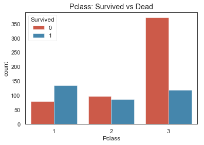

```python
sns.countplot('Pclass', hue="Survived", data = df_train)
plt.title('Pclass: Survived vs Dead')
plt.show()
```

### 6 - 2 -4 Multivariate Plots

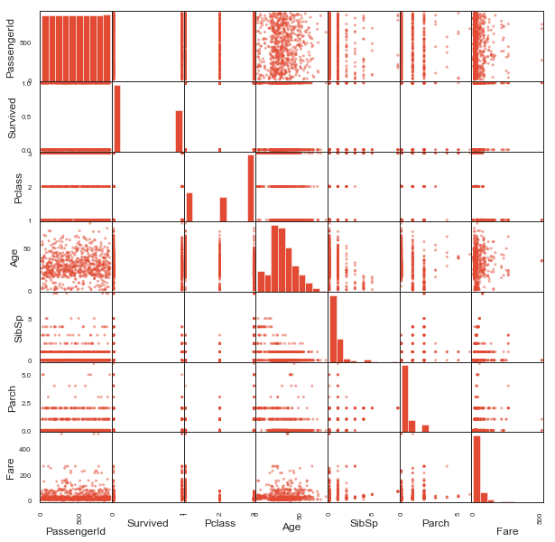

```python
pd.plotting.scatter_matrix(df_train,figsize=(10, 10))
plt.figure();
```

### 6 - 2 - 5 violinplots

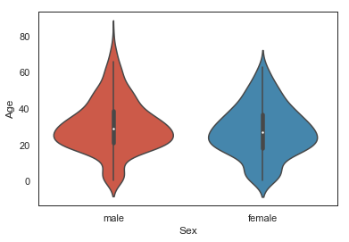

```python
sns.violinplot(data=df_train, x = "Sex", y="Age")
```

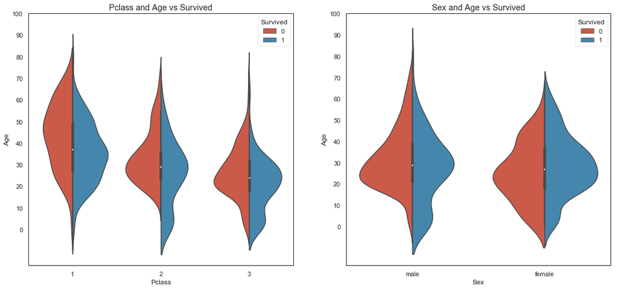

```python
f, ax = plt.subplots(1, 2, figsize=(18, 8))
sns.violinplot("Pclass", "Age", hue="Survived", data=df_train, split=True, ax=ax[0])
ax[0].set_title('Pclass and Age vs Survived')
ax[0].set_yticks(range(0, 110, 10))
sns.violinplot("Sex", "Age", hue="Survived", data=df_train, split=True, ax=ax[1])
ax[1].set_title('Sex and Age vs Survived')
ax[1].set_yticks(range(0, 110, 10))
plt.show()
```

### 6 - 2 - 7 pairplot

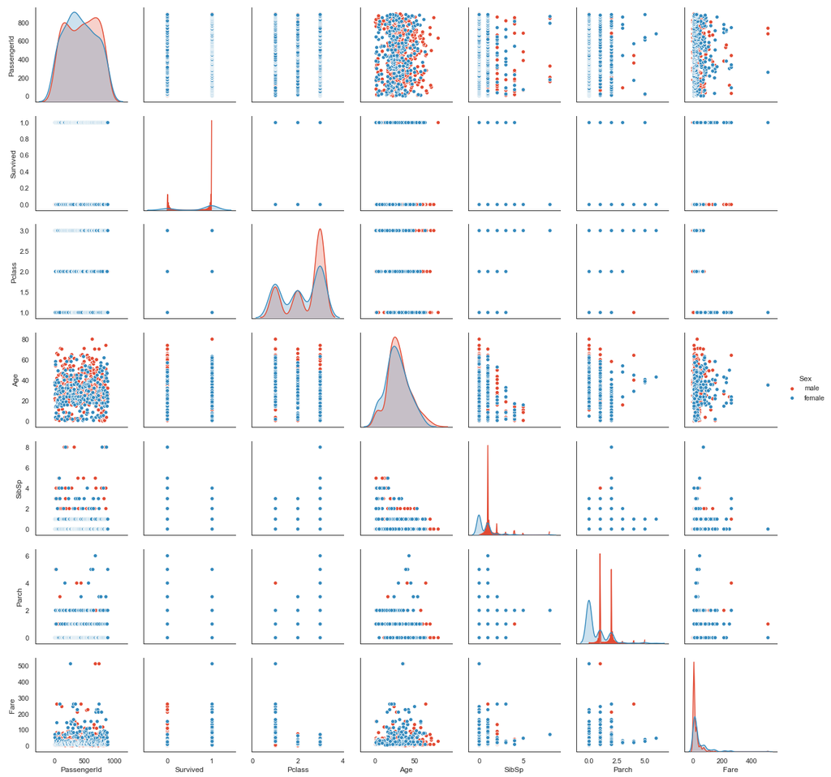

```python
sns.pairplot(df_train, hue="Sex")
```

### 6 - 2 - 8 kdeplot

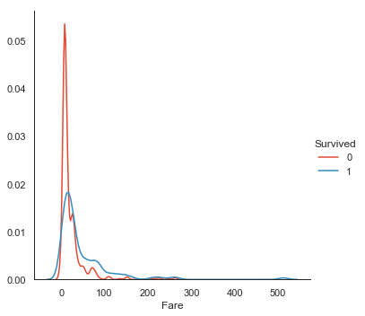

```python
sns.FacetGrid(df_train, hue="Survived", size = 5).map(sns.kdeplot, 'Fare').add_legend()
plt.show()
```

### 6 - 2 - 8 jointplot

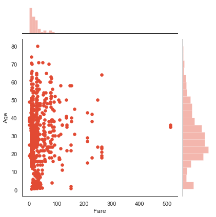

```python
sns.jointplot(x="Fare", y="Age", data=df_train)
```

### 6 - 2 - 9 Swarm plot

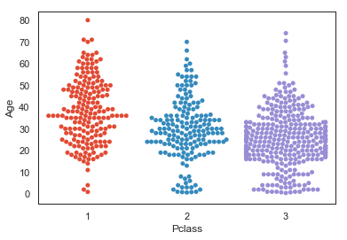

```python
sns.swarmplot(x="Pclass", y="Age", data=df_train)
```

### 6 - 2 - 10 Heatmap

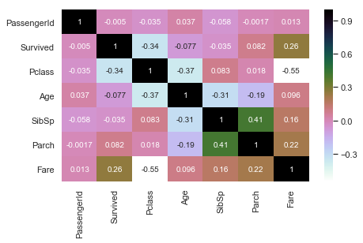

```python
plt.figure(figsize=(7, 4))
sns.heatmap(df_train.corr(), annot=True, cmap='cubehelix_r')
plt.show()
```

### 6 - 2 - 11 Bar Plot

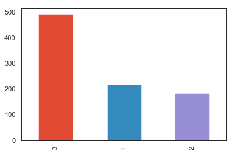

```python
df_train['Pclass'].value_counts().plot(kind="bar")
```

### 6 - 2 - 12 Factorplot

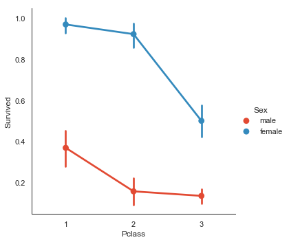

```python
sns.factorplot('Pclass','Survived', hue="Sex", data = df_train)
plt.show()
```

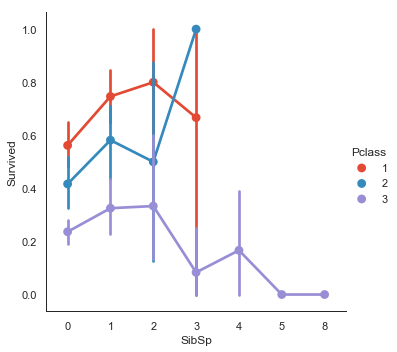

```python
sns.factorplot('SibSp','Survived', hue="Pclass", data = df_train)
plt.show()
```

### 6 - 2 - 13 distplot

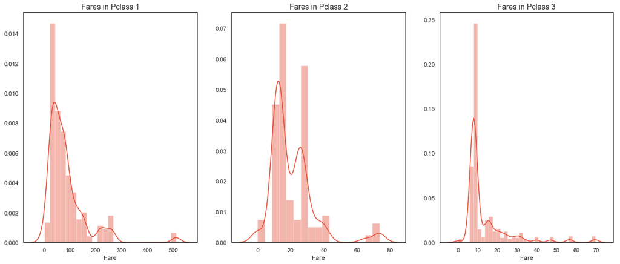

```python
f, ax=plt.subplots(1, 3, figsize=(20, 8))
sns.distplot(df_train[df_train['Pclass']==1].Fare, ax = ax[0])
ax[0].set_title('Fares in Pclass 1')
sns.distplot(df_train[df_train['Pclass'] == 2].Fare, ax=ax[1])
ax[1].set_title('Fares in Pclass 2')
sns.distplot(df_train[df_train['Pclass']==3].Fare, ax=ax[2])
ax[2].set_title('Fares in Pclass 3')
plt.show()
```

### 6 - 3 Data Preprocessing

데이터 전처리는 알고리즘을 적용하기 전에, 우리의 데이터에 적용되는 변화를 뜻한다.

데이터 전처리는 가공이 되지 않은 데이터를 깔끔한 데이터 셋으로 변환시킬때 사용되는 기술이다. 데이터는 각기 다른 통계자료로 부터 우리의 분석에 맞지 않는 형식을 가진 데이터를 얻는 경우가 많기 때문에 데이터 전처리가 필요하다.

데이터 전처리를 위한 과정은 매우 많다. 아래는 그 중 몇개를 나열해보았다.

- removing Target column (id)
- Sampling (without replacement)
- Dealing with Imbalanced Data
- Introducing missing values and treating them (replacing by average values)
- Noise filtering
- Data discretization
- Normalization and standardization
- PCA analysis
- Feature selection (filter, embedded, wrapper)

### 6 - 3 - 1 Features

- numeric
- categorical
- ordinal
- datetime
- coordinates

### 6 - 3 - 2 Explorer Dataset

1 - 데이터 셋의 차수  
2 - 데이터의 최고점  
3 - 모든 속성의 통계적인 요약  
4 - 클래스 변수에 의한 데이터 분류

```python
print(df_train.shape)
```

```
(891, 12)
```

```python
# How many NA elements in every column

def check_missing_data(df):
    flag=df.isna().sum().any()
    if flag == True:
        total = df.isnull().sum()
        percent = (df.isnull().sum())/(df.isnull().count()*100)
        output = pd.concat([total, percent], axis = 1, keys=['Total', 'Percent'])

        data_type=[]
        for col in df.columns:
            dtype = str(df[col].dtype)
            data_type.append(dtype)
        output['Types'] = data_type
        return(np.transpose(output))
    else:
        return(False)
```

```python
check_missing_data(df_train)
```

[output not shown]

```python
check_missing_data(df_test)
```

[output not shown]

```python
# remove rows that have NA's
# train = train.dropna()
```

```python
# for getting some information about the dataset you can use info() command

print(df_train.info())
```

```
<class 'pandas.core.frame.DataFrame'>
RangeIndex: 891 entries, 0 to 890
Data columns (total 12 columns):
PassengerId    891 non-null int64
Survived       891 non-null int64
Pclass         891 non-null int64
Name           891 non-null object
Sex            891 non-null object
Age            714 non-null float64
SibSp          891 non-null int64
Parch          891 non-null int64
Ticket         891 non-null object
Fare           891 non-null float64
Cabin          204 non-null object
Embarked       889 non-null object
dtypes: float64(2), int64(5), object(5)
memory usage: 83.6+ KB
None
```

```python
# To give a statical summary about the dataset, we can use **describe()

df_train.describe()
```

|  | PassengerId | Survived | Pclass | Age | SibSp | Parch | Fare |
| --- | --- | --- | --- | --- | --- | --- | --- |
| count | 891.000000 | 891.000000 | 891.000000 | 714.000000 | 891.000000 | 891.000000 | 891.000000 |
| mean | 446.000000 | 0.383838 | 2.308642 | 29.699118 | 0.523008 | 0.381594 | 32.204208 |
| std | 257.353842 | 0.486592 | 0.836071 | 14.526497 | 1.102743 | 0.806057 | 49.693429 |
| min | 1.000000 | 0.000000 | 1.000000 | 0.420000 | 0.000000 | 0.000000 | 0.000000 |
| 25% | 223.500000 | 0.000000 | 2.000000 | 20.125000 | 0.000000 | 0.000000 | 7.910400 |
| 50% | 446.000000 | 0.000000 | 3.000000 | 28.000000 | 0.000000 | 0.000000 | 14.454200 |
| 75% | 668.500000 | 1.000000 | 3.000000 | 38.000000 | 1.000000 | 0.000000 | 31.000000 |
| max | 891.000000 | 1.000000 | 3.000000 | 80.000000 | 8.000000 | 6.000000 | 512.329200 |

- 'Age' 중복 제거값

```python
df_train['Age'].unique()
```

```
array([22.  , 38.  , 26.  , 35.  ,   nan, 54.  ,  2.  , 27.  , 14.  ,
        4.  , 58.  , 20.  , 39.  , 55.  , 31.  , 34.  , 15.  , 28.  ,
        8.  , 19.  , 40.  , 66.  , 42.  , 21.  , 18.  ,  3.  ,  7.  ,
       49.  , 29.  , 65.  , 28.5 ,  5.  , 11.  , 45.  , 17.  , 32.  ,
       16.  , 25.  ,  0.83, 30.  , 33.  , 23.  , 24.  , 46.  , 59.  ,
       71.  , 37.  , 47.  , 14.5 , 70.5 , 32.5 , 12.  ,  9.  , 36.5 ,
       51.  , 55.5 , 40.5 , 44.  ,  1.  , 61.  , 56.  , 50.  , 36.  ,
       45.5 , 20.5 , 62.  , 41.  , 52.  , 63.  , 23.5 ,  0.92, 43.  ,
       60.  , 10.  , 64.  , 13.  , 48.  ,  0.75, 53.  , 57.  , 80.  ,
       70.  , 24.5 ,  6.  ,  0.67, 30.5 ,  0.42, 34.5 , 74.  ])
```

- 'Pclass' 값의 갯수

```python
df_train["Pclass"].value_counts()
```

```
3    491
1    216
2    184
Name: Pclass, dtype: int64
```

- 속성에 대한 정보 확인

```python
df_train.columns
```

```
Index(['PassengerId', 'Survived', 'Pclass', 'Name', 'Sex', 'Age', 'SibSp',
       'Parch', 'Ticket', 'Fare', 'Cabin', 'Embarked'],
      dtype='object')
```

- Query문을 이용한 검색

```python
df_train[df_train['Age']<7.2].head(2)
```

|  | PassengerId | Survived | Pclass | Name | Sex | Age | SibSp | Parch | Ticket | Fare | Cabin | Embarked |
| --- | --- | --- | --- | --- | --- | --- | --- | --- | --- | --- | --- | --- |
| 7 | 8 | 0 | 3 | Palsson, Master. Gosta Leonard | male | 2.0 | 3 | 1 | 349909 | 21.075 | NaN | S |
| 10 | 11 | 1 | 3 | Sandstrom, Miss. Marguerite Rut | female | 4.0 | 1 | 1 | PP 9549 | 16.700 | G6 | S |

### 6 - 4 Data Cleaning

Data Cleaning의 목표는 에러들과 변칙적인 데이터들을 감지하고 삭제하여 분석결과의 가치를 향상시키는 것이다.

### 6 - 4 - 1 Transforming Features

데이터 변형은 데이터를 한 형식에서 다른 형식으로 전환시키는 과정이다.

```python
def simplify_ages(df):
    df.Age = df.Age.fillna(-0.5)
    bins = (-1, 0, 5, 12, 18, 25, 35, 60, 120)
    group_names = ['Unknown', 'Baby', 'Child', 'Teenager', 'Student', 'Young Adult', 'Adult', 'Senior']
    categories = pd.cut(df.Age, bins, labels = group_names)
    df.Age = categories
    return df
```

```python
# 이해 필요
def simplify_cabins(df):
    df.Cabin = df.Cabin.fillna('N')
    df.Cabin = df.Cabin.apply(lambda x: x[0])
    return df
```

```python
def simplify_fares(df):
    df.Fare = df.Fare.fillna(-0.5)
    bins = (-1, 0, 8, 15, 31, 1000)
    group_names = ['Unknown', '1_quartile', '2_quartile', '3_quartile', '4_quartile']
    categories = pd.cut(df.Fare, bins, labels=group_names)
    df.Fare = categories
    return df
```

```python
# 이해 필요

def format_name(df):
    df['Lname'] = df.Name.apply(lambda x: x.split(' ')[0])
    df['NamePrefix'] = df.Name.apply(lambda x: x.split(' ')[1])
    return df
```

```python
def drop_features(df):
    return df.drop(['Ticket', 'Name', 'Embarked'], axis = 1)
```

```python
def transform_features(df):
    df = simplify_ages(df)
    df = simplify_cabins(df)
    df = simplify_fares(df)
    df = format_name(df)
    df = drop_features(df)
    return df
```

```python
df_train = transform_features(df_train)
df_test = transform_features(df_test)
df_train.head()
```

|  | PassengerId | Survived | Pclass | Sex | Age | SibSp | Parch | Fare | Cabin | Lname | NamePrefix |
| --- | --- | --- | --- | --- | --- | --- | --- | --- | --- | --- | --- |
| 0 | 1 | 0 | 3 | male | Student | 1 | 0 | 1_quartile | N | Braund, | Mr. |
| 1 | 2 | 1 | 1 | female | Adult | 1 | 0 | 4_quartile | C | Cumings, | Mrs. |
| 2 | 3 | 1 | 3 | female | Young Adult | 0 | 0 | 1_quartile | N | Heikkinen, | Miss. |
| 3 | 4 | 1 | 1 | female | Young Adult | 1 | 0 | 4_quartile | C | Futrelle, | Mrs. |
| 4 | 5 | 0 | 3 | male | Young Adult | 0 | 0 | 2_quartile | N | Allen, | Mr. |

### 6 - 4 - 2 Feature Encoding

기계학습 알고리즘은 숫자로된 값만을 읽을 수 있기 때문에, 문자로 표현된 카테고리들을 숫자 값으로 변환한다.

```python
# Todo

def encode_features(df_train, df_test):
    features = ['Fare', 'Cabin', 'Age', 'Sex', 'Lname', 'NamePrefix']
    df_combined = pd.concat([df_train[features], df_test[features]])

    for feature in features:
        le = preprocessing.LabelEncoder()
        le = le.fit(df_combined[feature])
        df_train[feature] = le.transform(df_train[feature])
        df_test[feature] = le.transform(df_test[feature])

    return df_train, df_test
```

### 7 - Model Deployment

### 7 - 1 Families of MA algorithms

머신러닝에는 다양한 알고리즘이 있다.

- Linear
  - Linear Regression
  - Logistic Regression
  - Support Vector Machines
- Tree-Based
  - Decision Tree
  - Random Forest
  - GBDT
- KNN
- Neural Networks

학습방법에 따른 타입은 아래와 같다.

- Classification
  - k-Nearest Neighbors
  - LinearRegression
  - SVM
  - DT
  - NN
- clustering
  - K-means
  - HCA
  - Expectation Maximization
- Visualization and dimensionality reduction
  - Principal Component Analysis(PCA)
  - Kernal PCA
  - Locally-Linear Embedding (LLE)
  - t-distributed Stochastic NeighborEmbedding (t-SNE)
- Association rule learning
  - Apriori
  - Eclat
- Semisupervised Learning
- ReinForcement Learning
  - Q-learning
- Batch learning & Online learning
- Ensemble Learning

### 7 - 2 Prepare Features & Targets

independent variables 와 dependent variables를 나눈다.

```python
df_train, df_test = encode_features(df_train, df_test)
df_train.head()
```

|  | PassengerId | Survived | Pclass | Sex | Age | SibSp | Parch | Fare | Cabin | Lname | NamePrefix |
| --- | --- | --- | --- | --- | --- | --- | --- | --- | --- | --- | --- |
| 0 | 1 | 0 | 3 | 1 | 4 | 1 | 0 | 0 | 7 | 100 | 19 |
| 1 | 2 | 1 | 1 | 0 | 0 | 1 | 0 | 3 | 2 | 182 | 20 |
| 2 | 3 | 1 | 3 | 0 | 7 | 0 | 0 | 0 | 7 | 329 | 16 |
| 3 | 4 | 1 | 1 | 0 | 7 | 1 | 0 | 3 | 2 | 267 | 20 |
| 4 | 5 | 0 | 3 | 1 | 7 | 0 | 0 | 1 | 7 | 15 | 19 |

### 7 - 3 How to prevent overfitting & underfitting?

1. Under-fitting = too simple  
   그래프에서 예측선이 모든 참 값을 포함시키지 못한다.
1. appropriate-fitting  
   그래프에서 예측 선이 모든 참 값을 포함시킨다. 물론, 항상 참 값만을 포함할 수는 없지만, 충분히 좋은 예측 선이라고 할 수 있다.
1. Over-fitting =too good to be true  
   기존 값들에 대한 매우 정확한 예측선을 나타낸다. 하지만, 새로운 값에 있어서는 기존의 데이터로부터 살짝 벗어나게 된다면, 예측에 일패할 수 있다.

```python
# Prepare X(features), y(target)

x_all = df_train.drop(['Survived', 'PassengerId'], axis = 1)
y_all = df_train['Survived']

num_test = 0.3
X_train, X_test, y_train, y_test = train_test_split(x_all, y_all, test_size = num_test, random_state = 100)
```

### 7 - 4 Accuracy and precision

타이타닉 문제는 이항 분류 문제이고, 평가를 위해선 정확성을 계산해야한다.

1. accuracy  
   점수는 생존자를 정확하게 예측한 퍼센테이지이다.
1. precision  
   In pattern recognition, information retrieval and binary classification, precision (also called positive predictive value) is the fraction of relevant instances among the retrieved instances,
1. recall  
   recall is the fraction of relevant instances that have been retrieved over the total amount of relevant instances.
1. F-score  
   the F1 score is a measure of a test's accuracy. It considers both the precision p and the recall r of the test to compute the score: p is the number of correct positive results divided by the number of all positive results returned by the classifier, and r is the number of correct positive results divided by the number of all relevant samples (all samples that should have been identified as positive). The F1 score is the harmonic average of the precision and recall, where an F1 score reaches its best value at 1 (perfect precision and recall) and worst at 0.
1. accuracy와 precision의 차이  
   "Accuracy" and "precision" are general terms throughout science. A good way to internalize the difference are the common "bullseye diagrams". In machine learning/statistics as a whole, accuracy vs. precision is analogous to bias vs. variance.

```python
result = None
```

### 7 - 4 RandomForestClassifier

여러 개의 의사결정나무를 만들고, 그들의 다수결로 결과를 결정하는 방법이다.

장점

- 대부분 좋은 결과를 가져다 준다.
- 단순하며, classification 과 regression 에 모두 쓸 수 있다.

```python
# Choose the type of classifier.

rfc = RandomForestClassifier()

# Choose some parameter combinations to try

parameters = {'n_estimators' : [4, 6, 9],
             'max_features' : ['log2', 'sqrt', 'auto'],
             'criterion' : ['entropy', 'gini'],
             'max_depth' : [2, 3, 5, 10],
             'min_samples_split': [2, 3, 5],
             'min_samples_leaf' : [1, 5, 8]
             }

# Type of scoring used to compare parameter combinations
acc_scorer = make_scorer(accuracy_score)

# Run the grid search
grid_obj = GridSearchCV(rfc, parameters, scoring=acc_scorer)
grid_obj = grid_obj.fit(X_train, y_train)

# Set the clf to the best combination of parameters
rfc = grid_obj.best_estimator_

# Fit the best algorithm to the data
rfc.fit(X_train, y_train)
```

```
RandomForestClassifier(bootstrap=True, class_weight=None, criterion='entropy',
            max_depth=5, max_features='log2', max_leaf_nodes=None,
            min_impurity_decrease=0.0, min_impurity_split=None,
            min_samples_leaf=1, min_samples_split=2,
            min_weight_fraction_leaf=0.0, n_estimators=9, n_jobs=None,
            oob_score=False, random_state=None, verbose=0,
            warm_start=False)
```

### 7 - 4 - 1 prediction

```python
rfc_prediction = rfc.predict(X_test)
rfc_score = accuracy_score(y_test, rfc_prediction)
print(rfc_score)
```

```
0.7835820895522388
```

### 7 - 6 Logistic Regression

```python
logreg = LogisticRegression()
logreg.fit(X_train, y_train)
```

```
LogisticRegression(C=1.0, class_weight=None, dual=False, fit_intercept=True,
          intercept_scaling=1, max_iter=100, multi_class='warn',
          n_jobs=None, penalty='l2', random_state=None, solver='warn',
          tol=0.0001, verbose=0, warm_start=False)
```

```python
logreg_prediction = logreg.predict(X_test)
logreg_score = accuracy_score(y_test, logreg_prediction)
print(logreg_score)
```

```
0.7947761194029851
```